# Speed Dating Evaluation

##### Daniel Wu, Cheuk-lun Cheung, Sarah Ye, Mukund Patil

#### Introduction

In this day and age, finding love may be hard for many individuals. Due to this struggle, many people have turned to speed dating as a possible solution. Speed dating is a formal matchmaking process where a number of people meet prospective partners in a short amount of time. In this project, we will be exploring a dataset from Kaggle of a speed dating experiment to answer the question of: can a person's intelligence, attractiveness, shared interests with their partner, and how important they see shared interests predict one's success in speed dating? This will be a classification problem; we are predicting for a label/categorical class (match or no match) using various observations.

The traits that we will be using from the dataset will be rated numerically. To determine the traits of each individual we will be using the judgment of the partners of the individual rather than the ratings the individuals gave themselves.

```r
install.packages("themis")

library(themis)
library(tidyverse)
library(tidymodels)
library(cowplot)
options(repr.matrix.max.rows = 6)
```

[output not shown]

```r
# load dataset in
speed_dating_full <- read_csv("https://raw.githubusercontent.com/Cheuklun/DCSI-Group-Project-/main/Speed%20Dating%20Data.csv")
speed_dating_full
```

A spec_tbl_df: 8378 × 195

| iid <dbl> | id <dbl> | gender <dbl> | idg <dbl> | condtn <dbl> | wave <dbl> | round <dbl> | position <dbl> | positin1 <dbl> | order <dbl> | ⋯ | attr3_3 <dbl> | sinc3_3 <dbl> | intel3_3 <dbl> | fun3_3 <dbl> | amb3_3 <dbl> | attr5_3 <dbl> | sinc5_3 <dbl> | intel5_3 <dbl> | fun5_3 <dbl> | amb5_3 <dbl> |
| --- | --- | --- | --- | --- | --- | --- | --- | --- | --- | --- | --- | --- | --- | --- | --- | --- | --- | --- | --- | --- |
| 1 | 1 | 0 | 1 | 1 | 1 | 10 | 7 | NA | 4 | ⋯ | 5 | 7 | 7 | 7 | 7 | NA | NA | NA | NA | NA |
| 1 | 1 | 0 | 1 | 1 | 1 | 10 | 7 | NA | 3 | ⋯ | 5 | 7 | 7 | 7 | 7 | NA | NA | NA | NA | NA |
| 1 | 1 | 0 | 1 | 1 | 1 | 10 | 7 | NA | 10 | ⋯ | 5 | 7 | 7 | 7 | 7 | NA | NA | NA | NA | NA |
| ⋮ | ⋮ | ⋮ | ⋮ | ⋮ | ⋮ | ⋮ | ⋮ | ⋮ | ⋮ | ⋱ | ⋮ | ⋮ | ⋮ | ⋮ | ⋮ | ⋮ | ⋮ | ⋮ | ⋮ | ⋮ |
| 552 | 22 | 1 | 44 | 2 | 21 | 22 | 19 | 10 | 10 | ⋯ | 8 | 5 | 7 | 6 | 7 | 9 | 5 | 9 | 5 | 6 |
| 552 | 22 | 1 | 44 | 2 | 21 | 22 | 3 | 10 | 16 | ⋯ | 8 | 5 | 7 | 6 | 7 | 9 | 5 | 9 | 5 | 6 |
| 552 | NA | 1 | 44 | 2 | 21 | 22 | 2 | 10 | 15 | ⋯ | 8 | 5 | 7 | 6 | 7 | 9 | 5 | 9 | 5 | 6 |

To begin this report, we first load in the data set into Jupyter. To perform this action, we download the CSV from the main site (https://www.kaggle.com/datasets/whenamancodes/speed-dating?resource=download) to our GitHub repository. Once it is loaded in, we would then obtain the file link and read the CSV as seen above. Once completed, we are able to see the full speed dating data set.

There are many columns on this data set. To generalize the information on this data set, many variables and information that should be explained with words are expressed as numerical values. While the full data set is stated below, many columns are filtered out as they are not useful for our case.

- “iid” and “id” are classifications of the participants in this experiment/data set.
- “Gender” is classified as 0 for male or 1 for female
- “prefo(x)” refers to how important the matched partner rates said “x” variable (from a rating of 0 to 10)
- “x_o” refers to rating by given partner at the night of the event on being “x”
- “x_important” refers to the preference of how important “x” variable is in another partner (these variables will be important to us).
- “x” refers to how well they rate themselves out of 10 based on said “x” variable or how interested they are in “x” subject.
- “Match” referring to (yes/no) if both parties said yes to match to one another, 0 being no match, 1 being a match.

```r
# change "match" to factor, select possible predictors
speed_dating <- speed_dating_full |>
    select(match, age, income,
           attr_o, amb_o, intel_o, sinc_o, fun_o, shar_o,
           pf_o_att, pf_o_amb, pf_o_int, pf_o_sin, pf_o_fun, pf_o_sha) |>
    mutate(match = as.factor(match))
```

In order to effectively wrangle and clean the data from the original download to the format necessary for the analysis, we had to decide which attributes were suitable for our question. In our proposal process, we had realized that our question was too broad and had brought in way too many attributes for an effective prediction. To support the new question we chose age, income, several character traits (attractiveness, ambitiousness, intelligence, sincerity, funniness, shared interests) and preferences for said character traits to perform an exploratory data analysis. We did this in the code by creating a new data frame called "speed_dating" from the full data and selected the possible predictors. Finally, we had to mutate “match” to factor in order to select the possible predictors that would relate to it.

```r
set.seed(1234)
# split the data into testing and training
sd_split <- initial_split(speed_dating, prop = 0.75, strata = match)
sd_train <- training(sd_split)
sd_test <- testing(sd_split)
```

Here we are splitting the speed_dating data set so that the predictor is able to take a random 75% of the full data set to learn/train the prediction method. We would then apply this trained prediction onto the remaining 25% of the full data set to test our accuracy.

```r
set.seed(1234)
# see the amount of matches (no = 0, yes = 1)
matches <- sd_train |>
    select(match) |>
    group_by(match) |>
    summarise(n = n())

matches
```

A tibble: 2 × 2

| match <fct> | n <int> |
| --- | --- |
| 0 | 5248 |
| 1 | 1035 |

For our exploratory data analysis, we will first put two different variables against each other in the form of point graphs to see if there are any noticeable trends with matches. This will help us decide the best predictors as any strong trends with match would be a sign of a strong predictor.

```r
# match is either 1 (yes) or 0 (no)

# age and income graph
eda_point_1 <- ggplot(sd_train, aes(x = age, y = income, color = as_factor(match))) +
    geom_point(alpha = 0.4) +
    labs(x = "Age", y = "Income", color = "Match (1:yes/0:no)",
         title = "Age vs Income") +
    theme(text = element_text(size = 15))
# rating by partner of sincerity and rating by partner of ambitiousness
eda_point_2 <- ggplot(sd_train, aes(x = sinc_o, y = amb_o, color = as_factor(match))) +
    geom_point(alpha = 0.4) +
    labs(x = "Sincerity", y = "Ambitiousness", color = "Match (1:yes/0:no)",
         title = "Sincerity vs Ambitiousness") +
    theme(text = element_text(size = 15))
# rating by partner of intelligence and rating by partner of attractiveness
eda_point_3 <- ggplot(sd_train, aes(x = intel_o, y = attr_o, color = as_factor(match))) +
    geom_point(alpha = 0.4) +
    labs(x = "Intelligence", y = "Attractiveness", color = "Match (1:yes/0:no)",
         title = "Intelligence vs Attractiveness") +
    theme(text = element_text(size = 15))
# rating by partner of funniness and rating by partner of shared interests
eda_point_4 <- ggplot(sd_train, aes(x = fun_o, y = shar_o, color = as_factor(match))) +
    geom_point(alpha = 0.4) +
    labs(x = "Funniness", y = "Shared Interets", color = "Match (1:yes/0:no)",
         title = "Funniness vs Shared Interests") +
    theme(text = element_text(size = 15))
# preference of sincerity and preference of ambitiousness
eda_point_5 <- ggplot(sd_train, aes(x = pf_o_sin, y = pf_o_amb, color = as_factor(match))) +
    geom_point(alpha = 0.4) +
    labs(x = "Preference of Sincerity", y = "Preference of Ambitiousness", color = "Match (1:yes/0:no)",
         title = "Preference of Sincerity vs Preference of Ambitiousness") +
    theme(text = element_text(size = 15))
# preference of intelligence and preference of attractiveness
eda_point_6 <- ggplot(sd_train, aes(x = pf_o_int, y = pf_o_att, color = as_factor(match))) +
    geom_point(alpha = 0.4) +
    labs(x = "Preference of Intelligence", y = "Preference of Attractiveness", color = "Match (1:yes/0:no)",
        title = "Preference of Intelligence vs Preference of Attractiveness") +
    theme(text = element_text(size = 15))
# preference of funniness and preference of shared interests
# preference of shared interests is not rated by specific interests, instead means how important shared interests are
eda_point_7 <- ggplot(sd_train, aes(x = pf_o_fun, y = pf_o_sha, color = as_factor(match))) +
    geom_point(alpha = 0.4) +
    labs(x = "Preference of Funniness", y = "Preference of Shared Interets", color = "Match (1:yes/0:no)",
        title = "Preference of Funniness vs Preference of Shared Interests") +
    theme(text = element_text(size = 15))
```

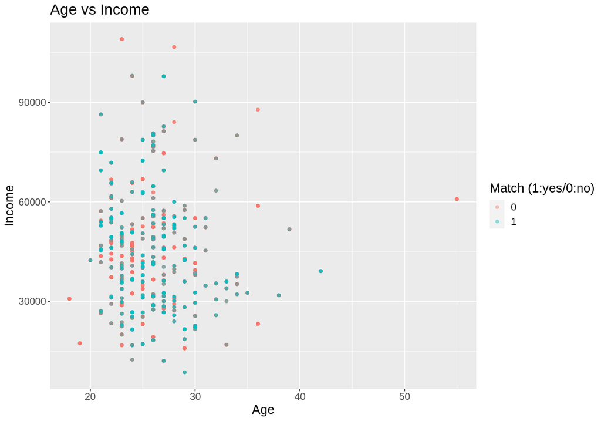

```r
# first we take a look at age vs income
options(repr.plot.width = 10, repr.plot.height = 7)

eda_point_1
```

"Age vs Income" does not have any strong trends. Most of the people that participated in the experiment are on the younger side, 20 to mid 30s, however no trends between the two predictors and matches are apparent.

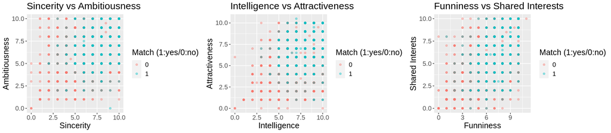

```r
# next we take a look at character traits rating by partner
options(repr.plot.width = 16, repr.plot.height = 3.5)

point_plot1 <- plot_grid(eda_point_2, eda_point_3, eda_point_4, ncol = 3)
point_plot1
```

All three of these graphs have similar trends, as the values for character traits increases, there are more matches. However, the second graph of "Intelligence vs Attractiveness" seems to have the strongest trend as the matches are more condensed in the top right compared to the others.

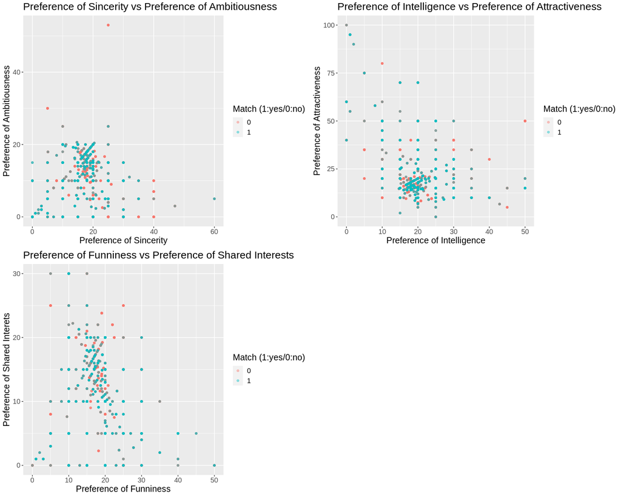

```r
# finally we take a look at preferences of character traits
options(repr.plot.width = 15, repr.plot.height = 12)

point_plot2 <- plot_grid(eda_point_5, eda_point_6, eda_point_7, ncol = 2)
point_plot2
```

Looking for trends is not the only method to look for the best predictors, looking at boxplots and their overlaps will help us finalize the predictors for this model.

```r
# boxplot for match and age
box1 <- ggplot(sd_train, aes(x = as_factor(match), y = age, fill = as_factor(match))) +
    geom_boxplot(color = "black") +
    labs(x = "Match", y = "Age", fill = "Match (1:yes/0:no)") +
    theme(text = element_text(size = 15))
# boxplot for match and income
box2 <- ggplot(sd_train, aes(x = as_factor(match), y = income, fill = as_factor(match))) +
    geom_boxplot(color = "black") +
    labs(x = "Match", y = "Income", fill = "Match (1:yes/0:no)") +
    theme(text = element_text(size = 15))
# boxplot for match and sincerity
box3 <- ggplot(sd_train, aes(x = as_factor(match), y = sinc_o, fill = as_factor(match))) +
    geom_boxplot(color = "black") +
    labs(x = "Match", y = "Sincerity", fill = "Match (1:yes/0:no)") +
    theme(text = element_text(size = 15))
# boxplot for match and ambitiousness
box4 <- ggplot(sd_train, aes(x = as_factor(match), y = amb_o, fill = as_factor(match))) +
    geom_boxplot(color = "black") +
    labs(x = "Match", y = "Ambitiousness", fill = "Match (1:yes/0:no)") +
    theme(text = element_text(size = 15))
# boxplot for match and age
box5 <- ggplot(sd_train, aes(x = as_factor(match), y = intel_o, fill = as_factor(match))) +
    geom_boxplot(color = "black") +
    labs(x = "Match", y = "Intelligence", fill = "Match (1:yes/0:no)") +
    theme(text = element_text(size = 15))
# boxplot for match and intelligence
box6 <- ggplot(sd_train, aes(x = as_factor(match), y = attr_o, fill = as_factor(match))) +
    geom_boxplot(color = "black") +
    labs(x = "Match", y = "Attractiveness", fill = "Match (1:yes/0:no)") +
    theme(text = element_text(size = 15))
# boxplot for match and attractiveness
box7 <- ggplot(sd_train, aes(x = as_factor(match), y = fun_o, fill = as_factor(match))) +
    geom_boxplot(color = "black") +
    labs(x = "Match", y = "Funniness", fill = "Match (1:yes/0:no)") +
    theme(text = element_text(size = 15))
# boxplot for match and funniness
box8 <- ggplot(sd_train, aes(x = as_factor(match), y = shar_o, fill = as_factor(match))) +
    geom_boxplot(color = "black") +
    labs(x = "Match", y = "Shared Interets", fill = "Match (1:yes/0:no)") +
    theme(text = element_text(size = 15))
# boxplot for match and shared interests
box9 <- ggplot(sd_train, aes(x = as_factor(match), y = pf_o_sin, fill = as_factor(match))) +
    geom_boxplot(color = "black") +
    labs(x = "Match", y = "Preference of Sincerity", fill = "Match (1:yes/0:no)") +
    theme(text = element_text(size = 15))
# boxplot for match and preference of sincerity
box10 <- ggplot(sd_train, aes(x = as_factor(match), y = pf_o_amb, fill = as_factor(match))) +
    geom_boxplot(color = "black") +
    labs(x = "Match", y = "Preference of Ambitiousness", fill = "Match (1:yes/0:no)") +
    theme(text = element_text(size = 15))
# boxplot for match and preference of ambitiousness
box11 <- ggplot(sd_train, aes(x = as_factor(match), y = pf_o_int, fill = as_factor(match))) +
    geom_boxplot(color = "black") +
    labs(x = "Match", y = "Preference of Intelligence", fill = "Match (1:yes/0:no)") +
    theme(text = element_text(size = 15))
# boxplot for match and preference of intelligence
box12 <- ggplot(sd_train, aes(x = as_factor(match), y = pf_o_att, fill = as_factor(match))) +
    geom_boxplot(color = "black") +
    labs(x = "Match", y = "Preference of Attractiveness", fill = "Match (1:yes/0:no)") +
    theme(text = element_text(size = 15))
# boxplot for match and preference of attractiveness
box13 <- ggplot(sd_train, aes(x = as_factor(match), y = pf_o_fun, fill = as_factor(match))) +
    geom_boxplot(color = "black") +
    labs(x = "Match", y = "Preference of Funniness", fill = "Match (1:yes/0:no)") +
    theme(text = element_text(size = 15))
# boxplot for match and preference of shared interests
box14 <- ggplot(sd_train, aes(x = as_factor(match), y = pf_o_sha, fill = as_factor(match))) +
    geom_boxplot(color = "black") +
    labs(x = "Match", y = "Preference of Shared Interets", fill = "Match (1:yes/0:no)") +
    theme(text = element_text(size = 15))
```

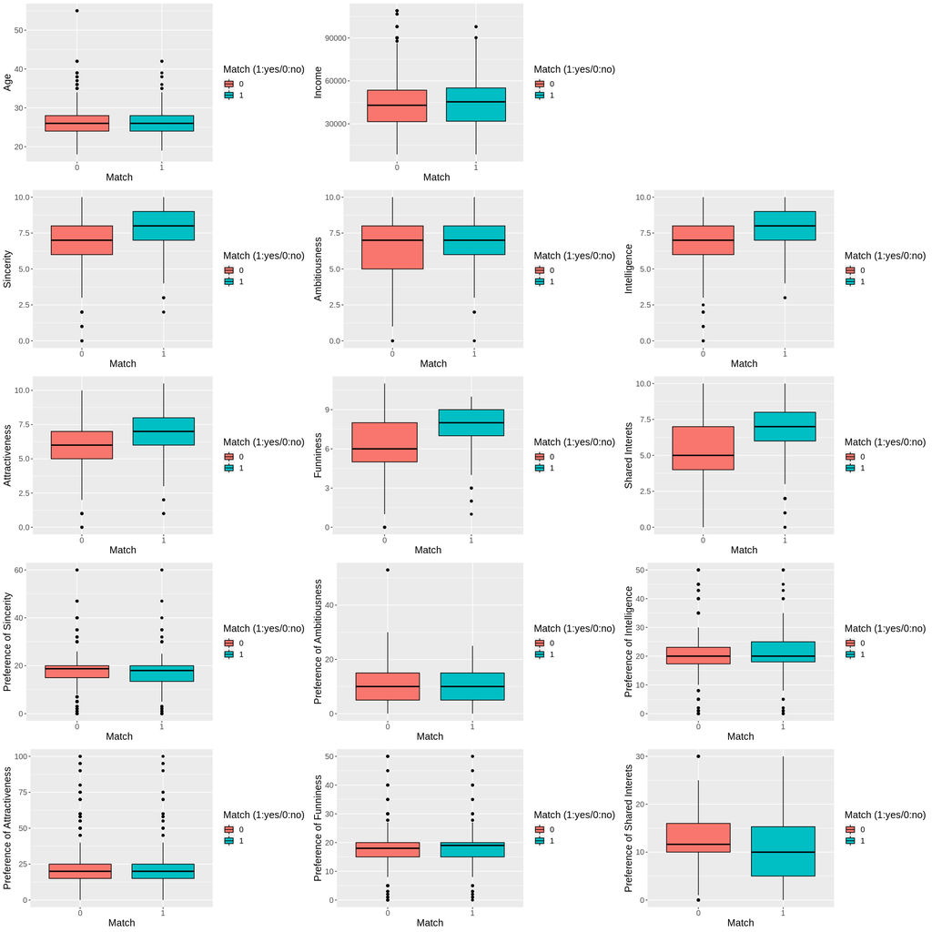

```r
options(repr.plot.width = 20, repr.plot.height = 20)

row1 <- plot_grid(box1, box2, ncol = 3)
row2 <- plot_grid(box3, box4, box5, ncol = 3)
row3 <- plot_grid(box6, box7, box8, ncol = 3)
row4 <- plot_grid(box9, box10, box11, ncol = 3)
row5 <- plot_grid(box12, box13, box14, ncol = 3)

plot_grid(row1, row2, row3, row4, row5, ncol = 1)
```

When we use boxplots, we are looking for the predictors that have the least overlap between yes/1 and no/0. For example, if we take a look at "Income" or "Age", we see that the two boxes are almost completely overlapped which would be a sign of a weak predictor.

```r
set.seed(1234)
# filter the testing and training data for the predictors we need and remove any NA values
sd_train1 <- sd_train |>
    select(match, intel_o, attr_o, shar_o, pf_o_sha) |>
    na.omit()
sd_test1 <- sd_test |>
    select(match, intel_o, attr_o, shar_o, pf_o_sha) |>
    na.omit()

# upscale the data to balance matches and non-matches
up_recipe <- recipe(match ~ ., data = sd_train1) |>
    step_upsample(match, over_ratio = 1, skip = FALSE) |>
    prep()

upsample_train <- bake(up_recipe, sd_train1)

upsample_train |>
    select(match) |>
    group_by(match) |>
    summarize(n = n())
```

A tibble: 2 × 2

| match <fct> | n <int> |
| --- | --- |
| 0 | 4452 |
| 1 | 4452 |

We have now completed the exploratory data analysis and picked the predictors of "Intelligence", "Attractiveness", "Shared Interests", and "Preference of Shared Interests". We want to separate these values from the original testing and training so we can remove any NAs. We do this by selecting from the original "sd_train" and "sd_test" into "sd_train1" and "sd_test1" respectively. However, we face a different issue which is the unbalanced yes/1 and no/0 values for match. We can counteract this by upscaling the data.

```r
set.seed(1234)
# recipe
sd_recipe <- recipe(match ~ ., data = upsample_train) |>
    step_scale(all_predictors()) |>
    step_center(all_predictors())

# nearest neighbour algorithim
knn_spec <- nearest_neighbor(weight_func = "rectangular", neighbors = tune()) |>
    set_engine("kknn") |>
    set_mode("classification")

# select folds and neighbours
sd_vfold <- vfold_cv(upsample_train, v = 10, strata = match)
gridvals <- tibble(neighbors = seq(1, 20))

# workflow
sd_results <- workflow() |>
    add_recipe(sd_recipe) |>
    add_model(knn_spec) |>
    tune_grid(resamples = sd_vfold, grid = gridvals) |>
    collect_metrics() |>
    filter(.metric == "accuracy")

sd_results
```

A tibble: 20 × 7

| neighbors <int> | .metric <chr> | .estimator <chr> | mean <dbl> | n <int> | std_err <dbl> | .config <chr> |
| --- | --- | --- | --- | --- | --- | --- |
| 1 | accuracy | binary | 0.6959780 | 10 | 0.003184994 | Preprocessor1_Model01 |
| 2 | accuracy | binary | 0.6857548 | 10 | 0.003969363 | Preprocessor1_Model02 |
| 3 | accuracy | binary | 0.7111334 | 10 | 0.003607701 | Preprocessor1_Model03 |
| ⋮ | ⋮ | ⋮ | ⋮ | ⋮ | ⋮ | ⋮ |
| 18 | accuracy | binary | 0.7029377 | 10 | 0.007509593 | Preprocessor1_Model18 |
| 19 | accuracy | binary | 0.7018151 | 10 | 0.006478021 | Preprocessor1_Model19 |
| 20 | accuracy | binary | 0.7021510 | 10 | 0.006190397 | Preprocessor1_Model20 |

Here we set up the recipe with the upscaled data predicting match as the target using the selected predictors. We proceed to create the nearest neighbour algorithm; this one is meant to find the ideal amount of neighbours. The mode is set to classification, we are predicting match or no match. "vfold_cv" is used on the upscaled training data to split for cross validation. We create a tibble to select how many neighbours we will be checking. Finally, we put everything together using "workflow" which will show us the accuracy for a range of neighbours/K.

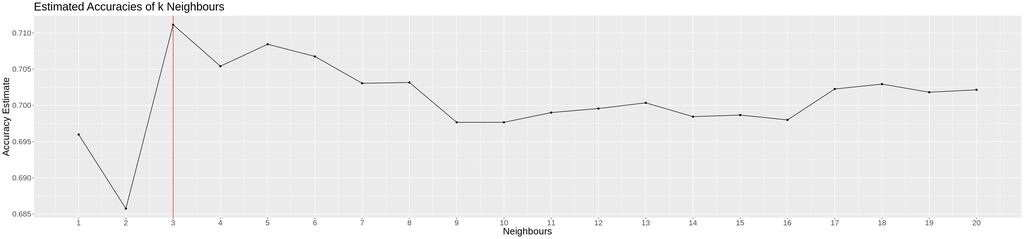

```r
options(repr.plot.width = 30, repr.plot.height = 7)
# plot to find best neighbours value
cross_val_plot <- sd_results |>
    ggplot(aes(x = neighbors, y = mean)) +
    geom_point() +
    geom_line() +
    geom_vline(xintercept = 3, colour = "red") +
    labs(x = "Neighbours",
         y = "Accuracy Estimate",
         title = "Estimated Accuracies of k Neighbours") +
    theme(text = element_text(size = 20)) +
    scale_x_continuous(breaks = 0:20)

cross_val_plot
```

We take the results from the workflow and graph it to look for the ideal number of neighbours. To find the neighbours that will yield the highest accuracy we look are looking for the point that is a peak and does not change much for K values that are close. In this case, there is an obvious peak at K = 3/three neighbours. While it is not very stable, there are not any better points so K = 3 will be the ideal number of neighbours for this prediction model.

```r
# nearest neighbour alogorithm
knn_best_spec <- nearest_neighbor(weight_func = "rectangular", neighbors = 3) |>
  set_engine("kknn") |>
  set_mode("classification")

# workflow
sd_fit <- workflow() |>
  add_recipe(sd_recipe) |>
  add_model(knn_best_spec) |>
  fit(data = sd_train1)

# predictions
sd_predictions <- predict(sd_fit, sd_test1) |>
    bind_cols(sd_test1)

# accuracy
sd_acc <- sd_predictions |>
    metrics(truth = match, estimate = .pred_class) |>
    select(.metric, .estimate) |>
    head(1)

# confusion matrix
sd_cm <- sd_predictions |>
    conf_mat(truth = match, estimate = .pred_class)

sd_acc

sd_cm
```

A tibble: 1 × 2

| .metric <chr> | .estimate <dbl> |
| --- | --- |
| accuracy | 0.8105502 |

```
          Truth
Prediction    0    1
         0 1386  259
         1   75   43
```

Now we redo the model of the nearest neighbour algorithm with K = 3, the ideal number of neighbours. With this, we are able to test the accuracy using the test split with "predict". After the prediction, we can check the accuracy with was around 81.05% and see the confusion matrix which compares our predictions to what the values actually are. Looking at this confusion matrix, we see that most of the predictions were 0/no. This does make sense as the data did have a greater number of noes compared to yeses. The poor predictions on yeses may be because the predictors were not great. This matches with what we found in the exploratory data analysis as none of the trends were extremely strong and all of the boxplots had some overlap.

#### Discussion

When we started this project, these were not the results we expected to find. Firstly, we expected there to be more correlations between traits that would lead to a solid prediction. However, after completing the first part of our exploratory data analysis, we saw that none of our graphs showed any particularly strong trends. After doing the second part of the exploratory data analysis with boxplots, we also found there was quite a bit of overlap in every plot. This was quite disappointing to see as it would mean that our final prediction would not be very accurate. A possible reason for the lack of trends is how complex humans are. The participants in the experiments probably did not judge their partners solely based off of traits. There is a much more complicated and thorough process that goes on in their minds that a computer may not be able to accurately predict. There are too many variables' participants go through during speed dating and they must make a decision based off of all of that, not just select traits.

These findings could have an important impact on the future of speed dating. The results show that it takes much more than a few variables or attributes to determine if an individual will be successful in speed dating. Humans are complicated beings with layered emotions and thoughts, it is near impossible to predict how attracted they feel towards another person using data. The complexity of humans and the results of this report show that speed dating is not a good method to find a desirable partner. A brief interaction between two people and judging solely off character traits and first impressions is not enough for humans to decide on a match, proving just how important taking the time to get to know someone really is. These findings are further supported by an article from socialeventsmelbourne.com, which found that the success rate of speed dating is only around 6%.

A fairly unsuccessful prediction led to quite a bit of reflection on our work, data, and question. Based on the previous parts of this discussion, it is clear that there were variables that were not accounted for which could have a large influence. Some include the way someone carries themself or the way they speak and interact. A person's behaviour would be something that would have a large influence on someone's decision, especially in a short amount of time. While this is something that we believe is of upmost importance, it can be difficult to measure behavioural manners in a way that could be used as a predictor. This further cements how hard it is to predict in speed dating, not only is speed dating itself highly ineffective, but the amount of variables that different individuals go through to say yes to a match is very unpredictable and hard to measure.

To conclude this report, we leave readers with a question to consider, is there a single variable that we did not explore that could have a large influence on one's perspective or would a collective number of traits have a larger influence?

#### References

- Chauhan, Aman. “Speed Dating.” Kaggle, 30 Sept. 2022, https://www.kaggle.com/datasets/whenamancodes/speed-dating?resource=download.
- “How Successful Is Speed Dating?” Melbourne Speed Dating, 31 Oct. 2022, https://socialeventsmelbourne.com.au/melbourne-speed-dating/cbd/successful/#:~:text=The%20chances%20of%20mating%20.
- Original Dating. “The History of Speed Dating.” Original Dating, 24 June 2014, https://www.originaldating.com/blog/2014/6/24/the-history-of-speed-dating/.
- Tiffany Timbers, Trevor Campbell. “Data Science.” Data Science, 24 Sept. 2022, https://datasciencebook.ca/.